# Biogeography Final Project1

Alden Schmidt

2024-12-13

#1 Research Question & Work Plan: (as plain text) Clearly define your research question and outline your work plan.

Work Plan: My first step is to map out the new species to find their trend of latitudinal shift in IV. I will calculate the sum of the pixels that I will aggregate by 0.5 or 1% latitudinally and longitudinally to find their range over the eastern United States. Next, I will study the population of adult trees versus saplings to see what their respected limits are, if that has changed in recent history, and what the predictive trend shows.

#2 R Code and Output: Include the R code you’ve written along with the corresponding output. Make sure to explain your code and its purpose clearly.

For my code, I had R read my file and then I told it to find the IV of each species by filtering to gather only common name and species and asking it to make the latitudinal sequence from minimum to maximum by 0.5. I set up the data frame to present that before then setting up the HOF model to show the latitudinal IV pattern. I then set up the species bands and LATbands to give the predicted response of the average IV. In the model, the grey dots represent the geom point, the black represents the geom line, and the red dashed line is the geom v line.

First species of study: Pawpaw.

[output not shown]

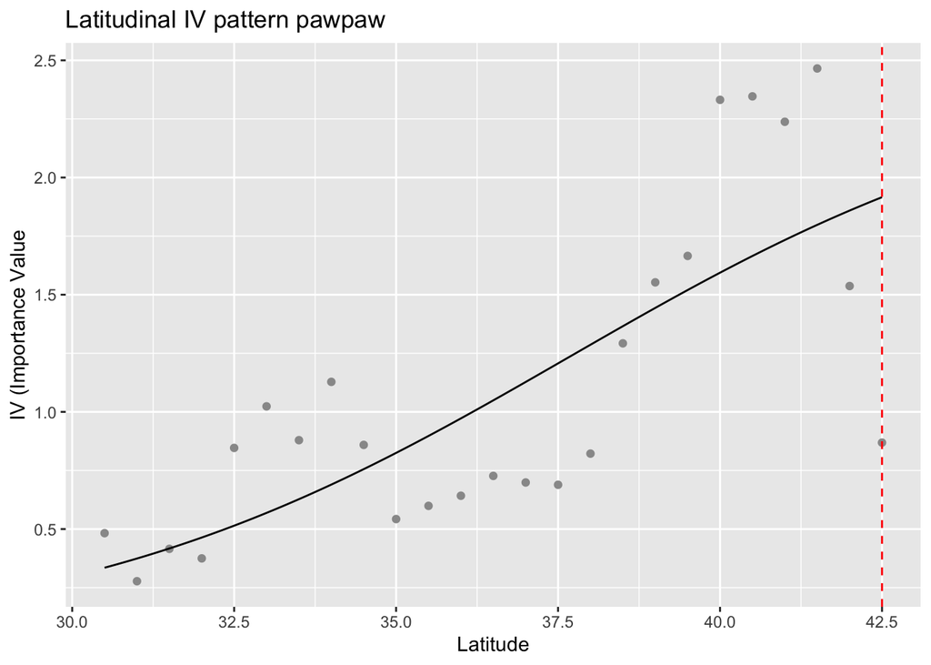

```r
iv <- readRDS ("~/Downloads/IV_data.RDS")
hof_plot <- function(species){
  pawpaw_data <- iv %>%
    filter(COMMON_NAME == species)
  lat_seq <- seq(from = floor(min(pawpaw_data$LAT)), to = ceiling(max(pawpaw_data$LAT)), by = 0.5)
  pawpaw_bands <- data.frame(
    Lat_band = lat_seq,
    avg_IV = numeric(length(lat_seq))
  )
  for (i in 1:length(lat_seq)){
    lat_min <- lat_seq[i] - 0.5
    lat_max <- lat_seq[i] + 0.5
    band_data <- pawpaw_data %>%
      filter(LAT >= lat_min & LAT <= lat_max)
    pawpaw_bands$avg_IV[i] <- mean(band_data$IV, na.rm = TRUE)
  }
  pawpaw_bands <- pawpaw_bands[complete.cases(pawpaw_bands$avg_IV),]
  hof_model <- HOF(
    pawpaw_bands$avg_IV,
    pawpaw_bands$Lat_band,
    modeltypes = c("I","II","III","IV","V"),
    family = gaussian,
    bootstrap = 100,
    test = 'AIC'
  )
  best_model <- pick.model(hof_model, modeltypes = c("I","II","III","IV","V"), test = 'AIC')
  predicted_response <- predict(hof_model, model = best_model,
                                newdata = seq(min(pawpaw_bands$Lat_band), max(pawpaw_bands$Lat_band), by = 0.1))
  scaled_response <- predicted_response * max(pawpaw_bands$avg_IV)
  ggplot(pawpaw_bands, aes(x = Lat_band, y = avg_IV)) +
    geom_point(color = "grey60") +
    geom_line(data = data.frame(lat_band = seq(min(pawpaw_bands$Lat_band),
                                               max(pawpaw_bands$Lat_band), by = 0.1),
                                predicted_IV = scaled_response),
              aes(x = lat_band, y = predicted_IV), color = "black") +
    geom_vline(xintercept = Para(hof_model, model = best_model)$opt, color = "red", linetype = "dashed") +
    labs(title = paste("Latitudinal IV pattern", species), x = "Latitude", y = "IV (Importance Value")

}

hof_plot("pawpaw")
```

```r
unique(iv$COMMON_NAME)
```

[output not shown]

[output cut: 128 more lines]

Second species of study: Common Persimmon.

[output not shown]

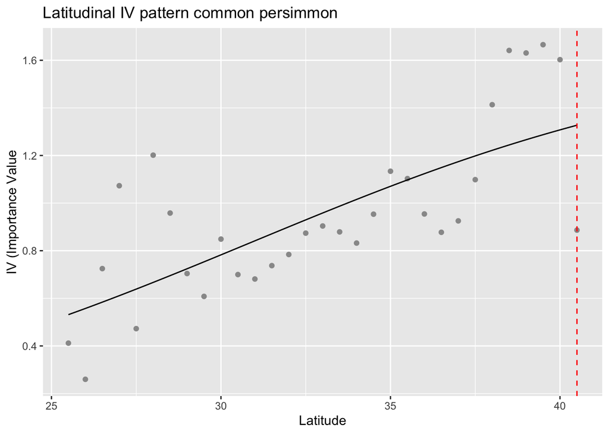

```r
hof_plot <- function(species){
  persimmon_data <- iv %>%
    filter(COMMON_NAME == species)
  lat_seq <- seq(from = floor(min(persimmon_data$LAT)), to = ceiling(max(persimmon_data$LAT)), by = 0.5)
  persimmon_bands <- data.frame(
    Lat_band = lat_seq,
    avg_IV = numeric(length(lat_seq))
  )
  for (i in 1:length(lat_seq)){
    lat_min <- lat_seq[i] - 0.5
    lat_max <- lat_seq[i] + 0.5
    band_data <- persimmon_data %>%
      filter(LAT >= lat_min & LAT <= lat_max)
    persimmon_bands$avg_IV[i] <- mean(band_data$IV, na.rm = TRUE)
  }
  persimmon_bands <- persimmon_bands[complete.cases(persimmon_bands$avg_IV),]
  hof_model <- HOF(
    persimmon_bands$avg_IV,
    persimmon_bands$Lat_band,
    modeltypes = c("I","II","III","IV","V"),
    family = gaussian,
    bootstrap = 100,
    test = 'AIC'
  )
  best_model <- pick.model(hof_model, modeltypes = c("I","II","III","IV","V"), test = 'AIC')
  predicted_response <- predict(hof_model, model = best_model,
                                newdata = seq(min(persimmon_bands$Lat_band), max(persimmon_bands$Lat_band), by = 0.1))
  scaled_response <- predicted_response * max(persimmon_bands$avg_IV)
  ggplot(persimmon_bands, aes(x = Lat_band, y = avg_IV)) +
    geom_point(color = "grey60") +
    geom_line(data = data.frame(lat_band = seq(min(persimmon_bands$Lat_band),
                                               max(persimmon_bands$Lat_band), by = 0.1),
                                predicted_IV = scaled_response),
              aes(x = lat_band, y = predicted_IV), color = "black") +
    geom_vline(xintercept = Para(hof_model, model = best_model)$opt, color = "red", linetype = "dashed") +
    labs(title = paste("Latitudinal IV pattern", species), x = "Latitude", y = "IV (Importance Value")

}

hof_plot("common persimmon")
```

#3 Future Work Plan: Write a brief description of the remaining steps you plan to take to complete your analysis.

Next steps are to use the IV graphs to illustrate the predictive trends of the Common Persimmon and Pawpaw trees.

By using time series analysis, I can examine data points collected at regular intervals in order to find trends or patterns over time. I will also be using the confidence interval to set my parameters of study. I will use the 95% confidence interval, because it provides a balance of a strict filter of data that may have been gathered with biases and a confidence that I will only have a chance of being wrong 5% of the time when testing the data.

For both species respectively, I will calculate the sum of the pixels that I will aggregate by 0.5 or 1% latitudinally and longitudinally (depending on what course of action is needed when I create the map) to find their range over the eastern United States. I will study the population of adult trees versus saplings to see what their respective limits are, if that has changed in recent history, and what the predictive trend shows.